# Praca domowa 2

Zofia Tarłowska

## Dane

Dane wykorzystane w Pracy domowej 2 dotyczą wyników egzaminów z 3 umiejętności: czytania, pisania i operacji matematycznych. Dodatkowo dostępne są podstawowe informacje o studentach i ich rodzicach. Opis wszystkich kolumn znajduje się również w pliku `README.md`.

| Zmienna | Opis |
| --- | --- |
| **gender** | płeć |
| **race.ethnicity** | pochodzenie etniczne |
| **parental.level.of.education** | wykształcenie rodziców |
| **lunch** | jaki obiad jedli uczniowie w dniu egzaminu |
| **test.preparation.course** | czy uczeń odbył kurs przygotowujący |
| **math.score** | wynik egzaminu z matematyki |
| **reading.score** | wynik egzaminu z czytania |
| **writing.score** | wynik egzaminu z pisania |

## Zadanie 1

Jak wyglądają rozkłady wyników uczniów z trzech przedmiotów (matematyka, czytanie, pisanie)?

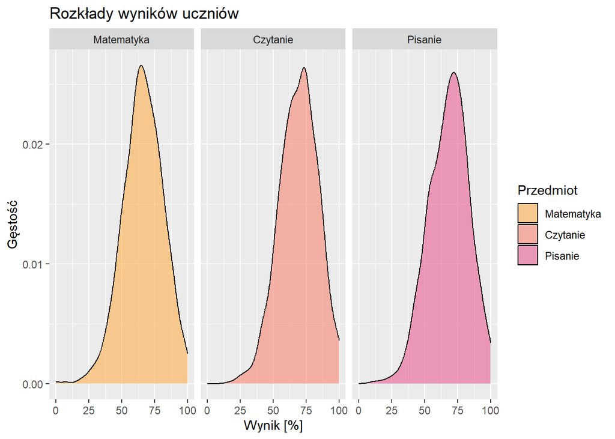

```r
df_long <- df %>%
  pivot_longer(cols = c(math.score, reading.score, writing.score),
               names_to  = "subject", values_to = "score")

  ggplot(df_long, aes(x = score, fill = subject)) +
  geom_density(alpha = 0.6) +
  facet_wrap(~subject, labeller = labeller(subject = c("math.score" = "Matematyka", "reading.score" = "Czytanie", "writing.score" = "Pisanie"))) +
  labs(title = "Rozkłady wyników uczniów", x = "Wynik [%]", y = "Gęstość", fill = "Przedmiot") +
  scale_fill_manual(values = c("#FFB14E", "#FA8775", "#EA5F94"), labels = c(math.score = "Matematyka", reading.score = "Czytanie", writing.score = "Pisanie"))
```

**Komentarz: Rozkłady wyników dla wszystkich trzech przedmiotów są podobne do rozkładu normalnego, jednak rozkład z matematyki jest trochę przesunięty w lewo, zatem wyniki z tego egzaminu były nieco niższe niż z pozostałych przedmiotów**

## Zadanie 2

Czy istnieje zauważalna różnica w wynikach między uczniami i uczennicami?

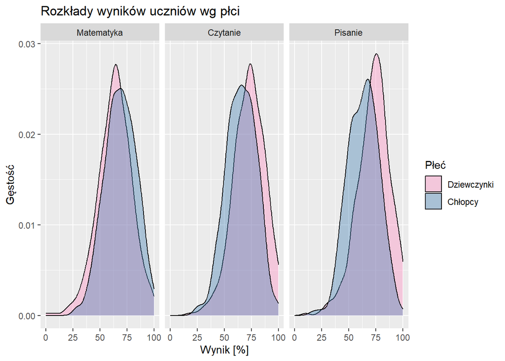

```r
df_long %>%
  ggplot(aes(x = score, fill = gender)) +
  geom_density(alpha = 0.4) +
  facet_wrap(~subject, labeller = labeller(subject = c("math.score" = "Matematyka", "reading.score" = "Czytanie", "writing.score" = "Pisanie"))) +
  labs(title = "Rozkłady wyników uczniów wg płci", x = "Wynik [%]", y = "Gęstość", fill = "Płeć") +
  scale_fill_manual(values = c(male = "steelblue", female = "#FF91C4"),
                  labels  = c(male = "Chłopcy",    female = "Dziewczynki"))
```

**Komentarz: Tak, istnieje zauważalna różnica. Uczennice osiągają wyższe wyniki w czytaniu i pisaniu. Natomiast krzywa z matematyki jest bardziej przesunięta w prawo u chłopców, co sugeruje, że uzyskują oni lepsze rezultaty od dziewczynek. U uczennic występuje również więcej wartości odstających.**

## Zadanie 3

Czy uczniowie, którzy ukończyli kurs przygotowawczy, osiągają lepsze wyniki niż pozostali?

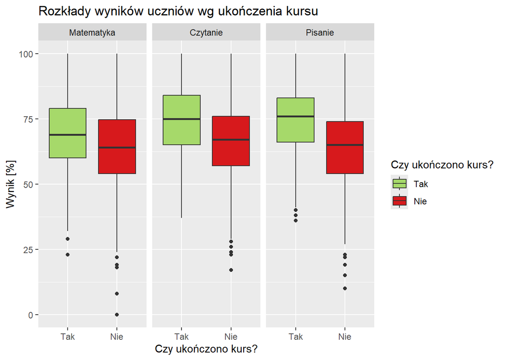

```r
df_long %>%
  ggplot(aes(x = test.preparation.course, y = score, fill = test.preparation.course)) +
  geom_boxplot() +
  facet_wrap(~subject, labeller = labeller(subject = c("math.score" = "Matematyka", "reading.score" = "Czytanie", "writing.score" = "Pisanie"))) +
  labs(title = "Rozkłady wyników uczniów wg ukończenia kursu", x = "Czy ukończono kurs?", y = "Wynik [%]", fill = "Czy ukończono kurs?") +
  scale_x_discrete(labels = c(completed = "Tak", none = "Nie")) +
  scale_fill_manual(values = c("completed" = "#a6d96a", "none" = "#d7191c"),
                    labels = c("completed" = "Tak", "none" = "Nie"))
```

**Komentarz: Tak, uczniowie, którzy ukończyli kurs przygotowawczy, osiągają z każdego przedmiotu lepsze wyniki niż pozostali. Największa różnica widoczna jest dla pisania, a najmniejsza - dla matematyki.**

## Zadanie 4

Jaki jest związek między poziomem wykształcenia rodziców a średnimi wynikami uczniów?

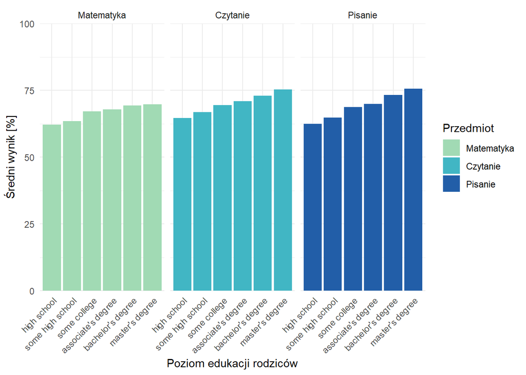

```r
df_long %>%
  group_by(parental.level.of.education, subject) %>%
  summarize(mean_score = mean(score)) %>%
  ggplot(aes(x = reorder(parental.level.of.education, mean_score), y = mean_score, fill = subject)) +
  geom_col() +
  facet_wrap(~ subject, labeller = labeller(subject = c("math.score" = "Matematyka", "reading.score" = "Czytanie", "writing.score" = "Pisanie"))) +
  scale_y_continuous(expand = c(0,0), limits = c(0,100)) +
  labs(x = "Poziom edukacji rodziców", y = "Średni wynik [%]", fill = "Przedmiot") +
  theme_minimal() +
  scale_x_discrete(guide = guide_axis(angle = 45)) +
  scale_fill_manual(values = c("#a1dab4", "#41b6c4", "#225ea8"),
                      labels = c("Matematyka", "Czytanie", "Pisanie"))
```

## Zadanie 5

Czy płeć i wykształcenie rodzica wpływa na wynik z matematyki?

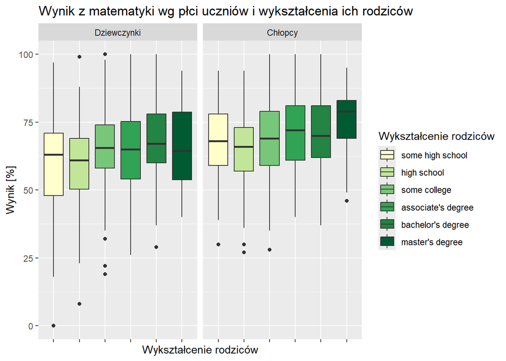

```r
df_long %>%
  filter(subject == "math.score") %>%
  mutate(parental.level.of.education = forcats::fct_relevel(
    parental.level.of.education, "some high school", "high school", "some college", "associate's degree", "bachelor's degree", "master's degree")) %>%
  ggplot(aes(x = parental.level.of.education, y = score, fill = parental.level.of.education)) +
    geom_boxplot() +
    facet_wrap(~ gender, labeller = labeller(gender = c("male" = "Chłopcy", "female" = "Dziewczynki"))) +
    labs(title = "Wynik z matematyki wg płci uczniów i wykształcenia ich rodziców", x = "Wykształcenie rodziców", y = "Wynik [%]",
         fill = "Wykształcenie rodziców") +
    theme(axis.text.x = element_blank()) +
    scale_fill_manual(values = c("#ffffcc", "#c2e699", "#78c679", "#31a354", "#238443", "#005a32"))
```

**Komentarz: Zarówno płeć, jak i poziom wykształcenia rodziców wpływają na wynik z matematyki. Na wykresach dla obu płci widać, że w większości przypadków wyższe wykształcenie rodzica przekłada się na wyższy wynik dziecka, a chłopcy osiągają wyższe wyniki porównując każdą z kategorii wykształcenia rodziców.**

## Zadanie 6

Czy istnieje zależność między wynikami z matematyki a wynikami z czytania lub pisania?

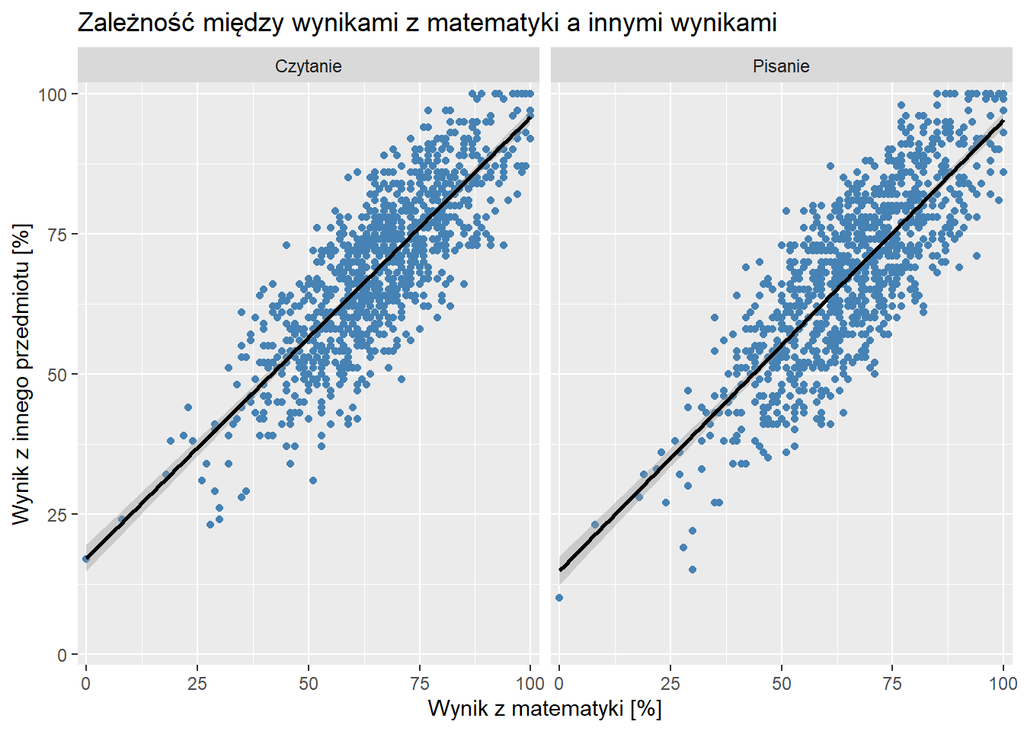

```r
df %>%
  select(c(math.score, reading.score, writing.score)) %>%
  pivot_longer(cols = c(reading.score, writing.score), names_to = "subject", values_to = "score") %>%
  ggplot(aes(x = math.score, y = score)) +
  geom_point(color = "steelblue") +
  geom_smooth(method = "lm", color = "black")+
  facet_wrap(~subject, labeller = labeller(subject = c("math.score" = "Matematyka", "reading.score" = "Czytanie", "writing.score" = "Pisanie"))) +
  scale_y_continuous(expand = c(0,0), limits = c(-2,102)) +
  scale_x_continuous(expand = c(0,0), limits = c(-2,102)) +
  labs(title = "Zależność między wynikami z matematyki a innymi wynikami",
       x = "Wynik z matematyki [%]",
       y = "Wynik z innego przedmiotu [%]") +
  theme(legend.position = "None")
```

**Komentarz: Tak, istnieje silna zależność liniowa między wynikami z matematyki a wynikami z czytania lub pisania. W obu przypadkach punkty układają się wzdłuż linii regresji i mają małe odchylenia.**